In this problem we will investigate the United States Gross Domestic Product (GDP). The data file `gdp.csv` contains the real US GDP, quarterly, from 1946, Q4 to 2014 Q2, seasonally adjusted and inflation adjusted, in billions of 2009 dollars.

## Part A

We read the data file and extract the `date` and `gdp` columns with the following commands:

```r
library(ggplot2)
data <- read.csv("http://ptrckprry.com/course/forecasting/data/gdp.csv")
date <- as.Date(data$date)
gdp <- data$gdp
```

Here is a plot of the GDP series versus date:

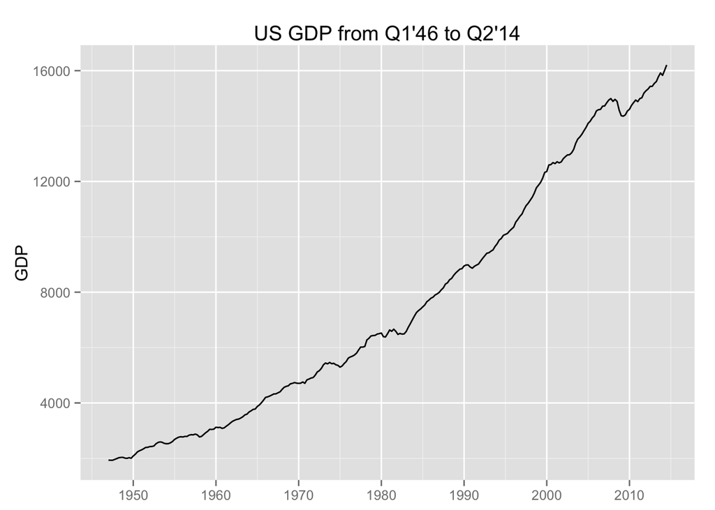

```r
ggplot() + geom_line(aes(date, gdp)) + ylab("GDP") + xlab(NULL) + labs(title = "US GDP from Q1'46 to Q2'14")
```

**Does GDP seem to grow linearly over time?**

## Part B

Here is a plot of log(GDP).

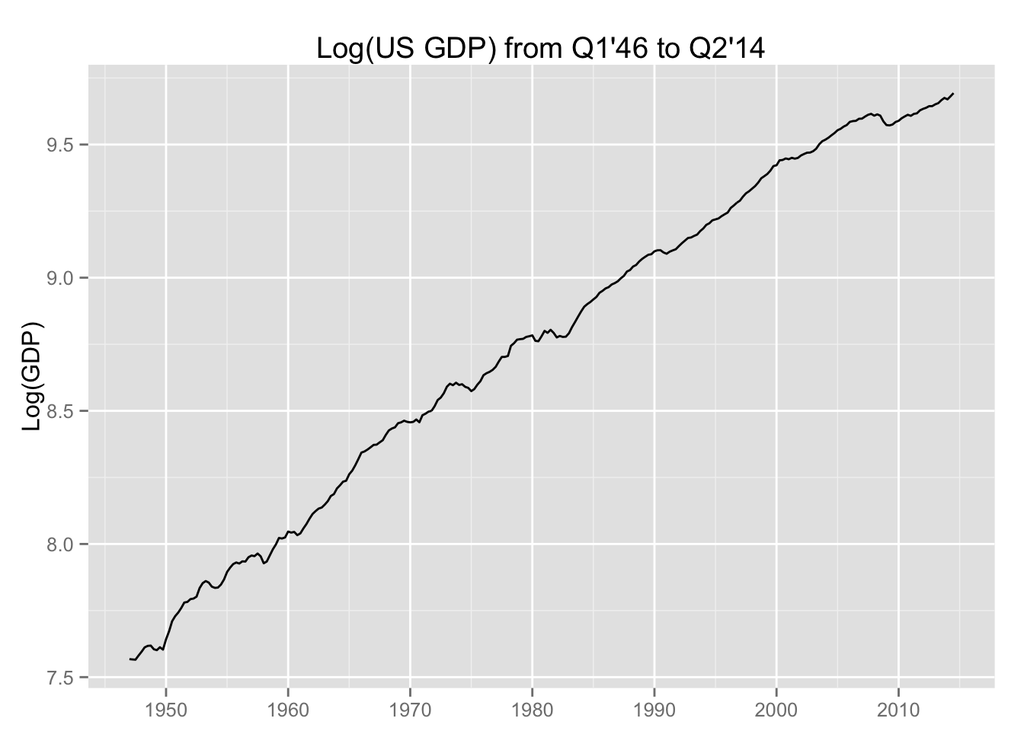

```r
log.gdp <- log(gdp) # create the log(GDP) variable
ggplot() + geom_line(aes(date, log.gdp)) + ylab("Log(GDP)") + xlab(NULL) + labs(title = "Log(US GDP) from Q1'46 to Q2'14")
```

**Does log GDP appear to grow linearly over time? If so, then what does this imply about the growth of GDP itself?**

Log GDP grows linearly over time. This approach mitigates for level-dependent volatility which can be seen in the prior graph.

## Part C

We fit an ordinary linear regression model for log(GDP), using time as the predictor variable.

```r
log.gdp <- log(gdp)

time <- 1:length(gdp) # create the time variable
model <- lm(log.gdp ~ time)
model
```

```
##
## Call:
## lm(formula = log.gdp ~ time)
##
## Coefficients:
## (Intercept)         time
##    7.647331     0.008088
```

Based on the fitted model, we forecast the log(GDP) for the third quarter of the year 2014 (time = 272).

```r
newdata <- data.frame(time = 272)
predict(model, newdata)
```

```
##        1
## 9.847186
```

We also construct a 95% prediction interval to go with the point forecast:

```r
predict(model, newdata, interval = 'prediction', level = .95)
```

```
##        fit      lwr      upr
## 1 9.847186 9.729679 9.964694
```

**Do you think this interval forecast (prediction interval) is valid? Does it seem too wide, or too precise? Explain.**

## Part D

Next is a plot of the log(GDP) series with the fitted line superimposed.

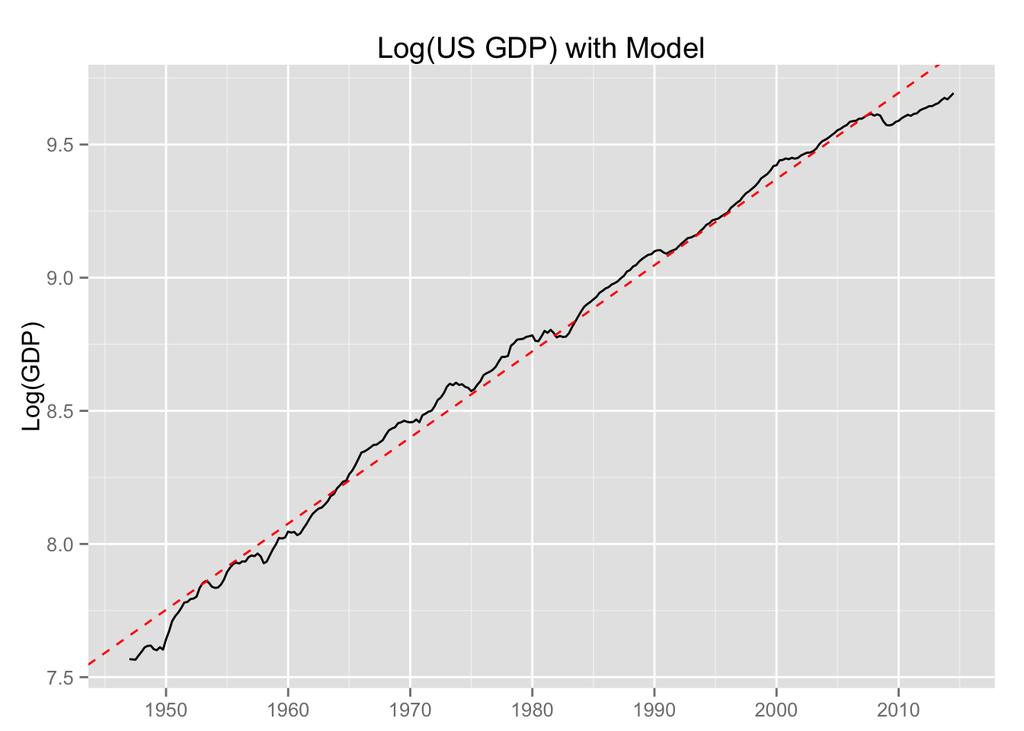

```r
ggplot() + geom_line(aes(date, log.gdp)) + geom_abline(intercept = 8.400e+00 , slope = 8.857e-05, color = 'red', linetype = 'dashed') + ylab("Log(GDP)") + xlab(NULL) + labs(title = "Log(US GDP) with Model")
```

**Does the line fit well?**

## Part E

Here is a plot the residuals from the fitted line versus time.

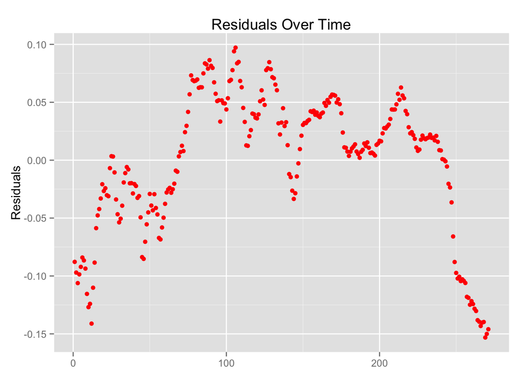

```r
res <- residuals(model)
ggplot() + geom_point(aes(time, res), colour = 'red') + labs(title = "Residuals Over Time") + ylab("Residuals") + xlab(NULL)
```

**What potential problems with the linear model are indicated by this plot? Do you think these problems could spoil the validity of the forecast interval?**